[figure not shown]

# INSCOM Group Predictions

#### CBS Sports

This week we beat or tied 5 of 8 CBS Sports’ Experts.

For the season we are currently beating or tied with 2 of 8 CBS Sports’ Experts.

#### ESPN

We also beat or tied 9 of 9 ESPN Experts.

For the season we are currently beating or tied with 4 of 11 ESPN Experts.

### Win percentage for the week

[interactive chart not shown]

### Season Win Percentage

[interactive chart not shown]

### Games Correct

144

### Games Picked

236

### Number of predictions

15

This Week's INSCOM G3 Predictions

Week 16

| Game | Prediction | Winner | Correct | Correct Votes | Correct Percent |
| --- | --- | --- | --- | --- | --- |
| 1 | Tennessee Titans | Tennessee Titans | Yes | 8 | 0.5333 |
| 2 | Green Bay Packers | Green Bay Packers | Yes | 14 | 0.9333 |
| 3 | Arizona Cardinals | Indianapolis Colts | No | 4 | 0.2667 |
| 4 | New England Patriots | Buffalo Bills | No | 4 | 0.2667 |
| 5 | Cincinnati Bengals | Cincinnati Bengals | Yes | 10 | 0.6667 |
| 6 | Atlanta Falcons | Atlanta Falcons | Yes | 13 | 0.8667 |
| 7 | New York Jets | New York Jets | Yes | 14 | 0.9333 |
| 8 | Los Angeles Chargers | Houston Texans | No | 1 | 0.0667 |
| 9 | Los Angeles Rams | Los Angeles Rams | Yes | 13 | 0.8667 |
| 10 | Philadelphia Eagles | Philadelphia Eagles | Yes | 13 | 0.8667 |
| 11 | Tampa Bay Buccaneers | Tampa Bay Buccaneers | Yes | 15 | 1.0000 |
| 12 | Seattle Seahawks | Chicago Bears | No | 4 | 0.2667 |
| 13 | Las Vegas Raiders | Las Vegas Raiders | Yes | 10 | 0.6667 |
| 14 | Kansas City Chiefs | Kansas City Chiefs | Yes | 14 | 0.9333 |
| 15 | Dallas Cowboys | Dallas Cowboys | Yes | 14 | 0.9333 |
| 16 | New Orleans Saints | Miami Dolphins | No | 4 | 0.2667 |

[interactive chart not shown]

# INSCOM Individual Predictions

#### Best Picks of the Week.

Frank Czerniakowski, Ira Crofford, Shane Clark, Tina Hartley

#### Best Season Correct Percentage

Frank Czerniakowski

#### Best Adjusted Season Correct Percentage

Frank Czerniakowski

- Adjusted season percentage accounts for the number of weeks picked.

## row

### Individual Table

INSCOM G3 Individual Results

Week 16

Name

Weekly # Correct

Percent

Weeks Picked

Season Percent

Adj Season Percent

Season Trend

Week 1

Week 2

Week 3

Week 4

Week 5

Week 6

Week 7

Week 8

Week 9

Week 10

Week 11

Week 12

Week 13

Week 14

Week 15

Week 16

Frank Czerniakowski

8

11

13

10

14

10

8

8

8

7

10

9

9

12

11

12

0.7500

16

0.6780

0.6780

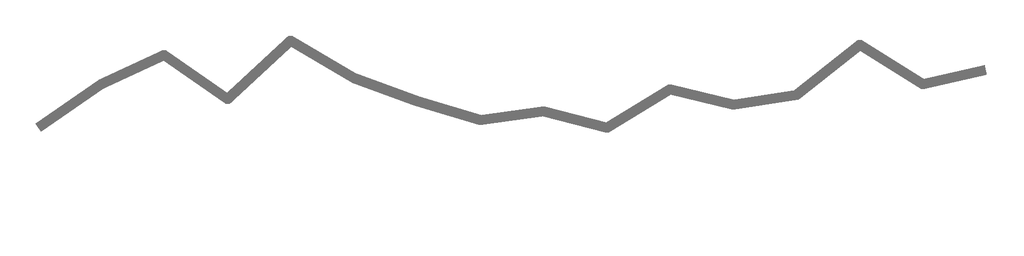

Ira Crofford

7

10

12

9

12

10

10

9

8

7

10

6

8

10

9

12

0.7500

16

0.6314

0.6314

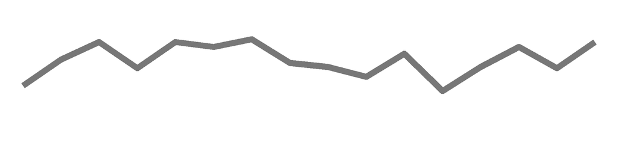

Shane Clark

5

10

7

NA

12

11

8

8

NA

7

9

7

8

9

9

12

0.7500

14

0.5922

0.5182

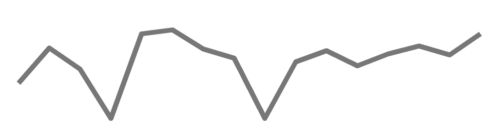

Tina Hartley

8

7

8

6

9

8

7

8

4

5

6

8

9

9

7

12

0.7500

16

0.5127

0.5127

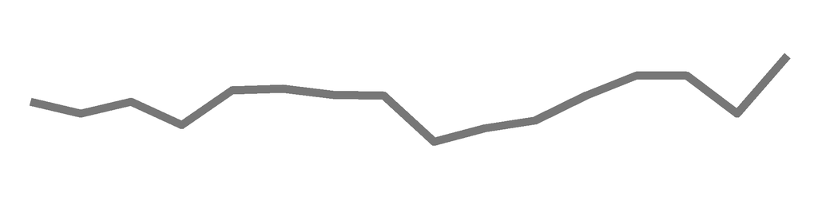

Jonathan Roginski

6

10

10

10

13

9

10

7

7

6

10

9

9

9

10

11

0.6875

16

0.6186

0.6186

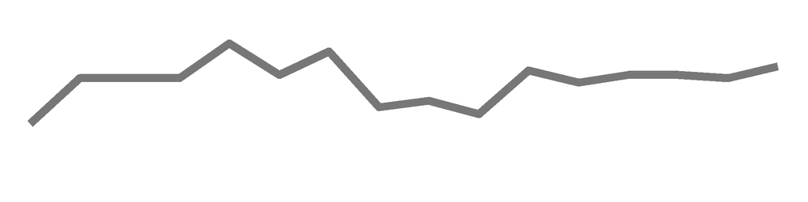

Blake Schwartz

10

6

8

5

11

9

9

9

7

5

9

5

9

9

10

11

0.6875

16

0.5593

0.5593

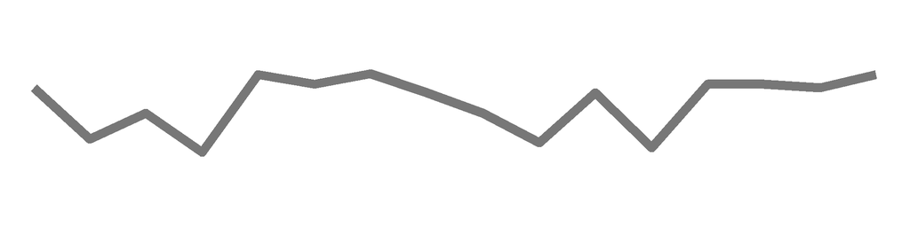

Michael Prokos

9

12

11

NA

12

8

9

7

8

7

8

8

9

11

10

10

0.6250

15

0.6318

0.5923

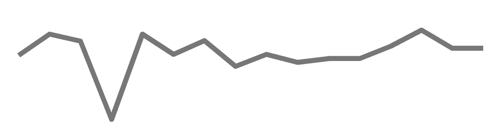

Matthew Rogers

9

10

11

8

14

9

10

NA

7

6

10

6

8

10

9

10

0.6250

15

0.6171

0.5785

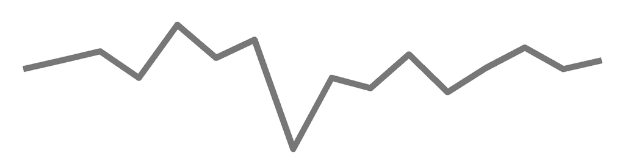

Daniel Baller

8

8

12

8

12

9

9

9

10

5

8

6

9

10

10

10

0.6250

16

0.6059

0.6059

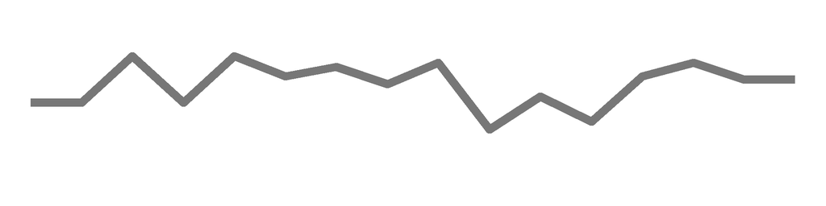

Gabriel Costa

8

8

10

8

11

11

9

6

5

7

9

10

9

10

8

10

0.6250

16

0.5890

0.5890

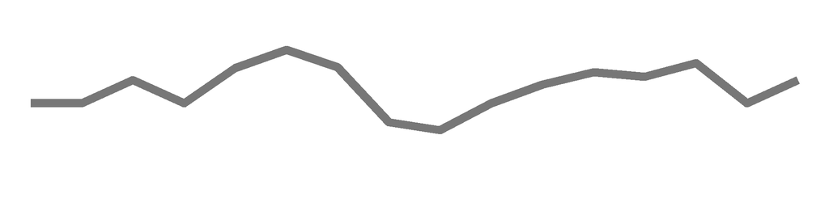

James Starling

7

10

9

9

11

9

6

9

6

5

8

9

7

11

9

10

0.6250

16

0.5720

0.5720

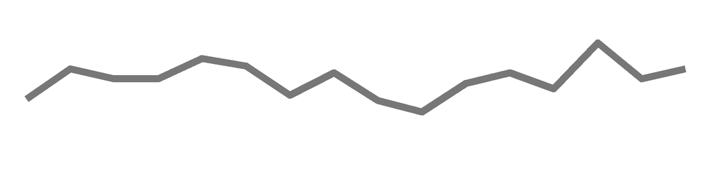

Eric Swenson

9

7

7

6

11

10

9

7

6

7

8

8

7

8

9

10

0.6250

16

0.5466

0.5466

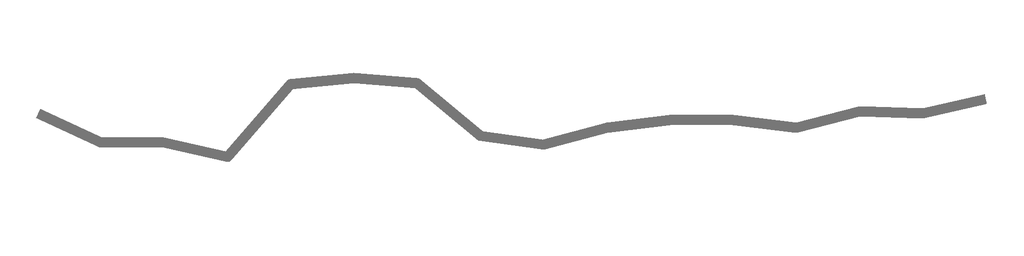

Josephine Cammack

9

9

6

8

12

8

9

8

4

6

6

7

9

9

9

10

0.6250

16

0.5466

0.5466

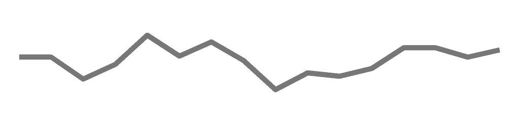

Jeremy Reynolds

8

10

9

9

13

10

9

9

7

7

11

7

8

11

10

9

0.5625

16

0.6229

0.6229

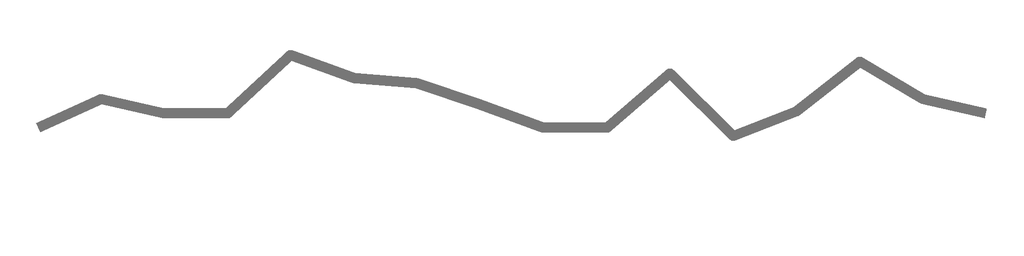

Margaret Grogan

6

10

10

8

10

7

7

9

9

8

7

5

8

8

10

6

0.3750

16

0.5424

0.5424

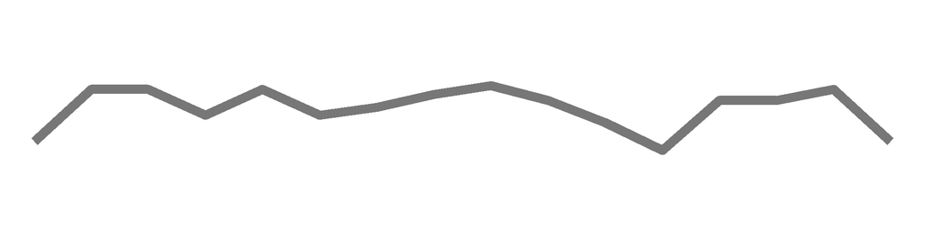

Welvin Lucero

8

8

10

NA

12

9

NA

9

9

7

10

NA

9

11

NA

NA

0.0000

11

0.6296

0.4328

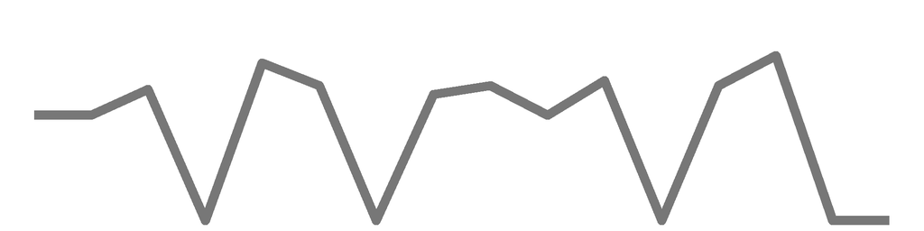

William Freiberg

10

10

9

9

13

9

9

9

8

6

9

8

9

10

9

NA

0.0000

15

0.6227

0.5838

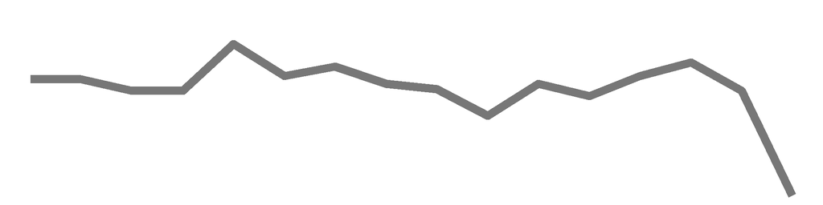

Nicholas Reisweber

11

10

9

7

10

9

10

9

NA

5

10

9

9

8

7

NA

0.0000

14

0.5971

0.5225

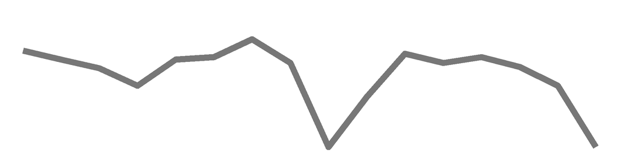

Leslie Jones

15

8

10

9

7

9

9

10

8

NA

6

NA

5

NA

NA

NA

0.0000

11

0.5963

0.4100

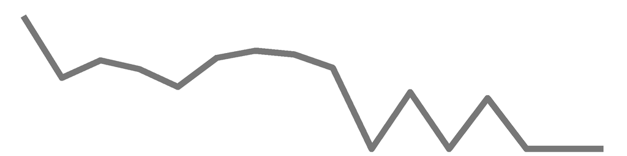

John Kearby

8

9

12

9

11

8

NA

8

8

5

9

NA

NA

NA

NA

NA

0.0000

10

0.5800

0.3625

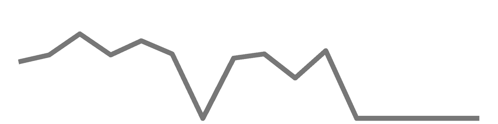

Cherri Gound

10

6

10

9

11

9

10

7

6

6

7

5

9

10

11

NA

0.0000

15

0.5727

0.5369

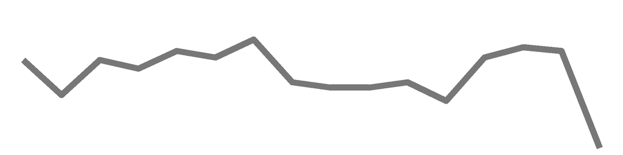

Evangeline Reynolds

8

8

NA

11

11

6

NA

NA

NA

NA

NA

NA

NA

NA

NA

NA

0.0000

5

0.5714

0.1786

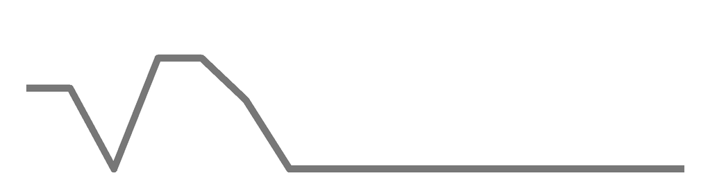

Kevin Cummiskey

9

8

10

NA

10

9

NA

8

6

NA

NA

5

9

10

7

NA

0.0000

11

0.5549

0.3815

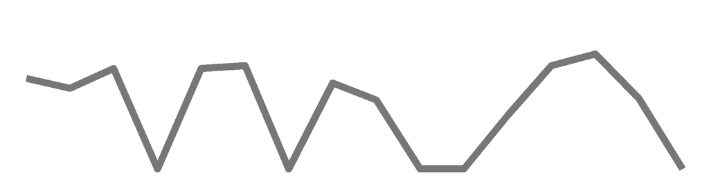

Patrick Mugg

7

8

11

7

9

10

8

9

5

6

8

6

9

8

11

NA

0.0000

15

0.5545

0.5198

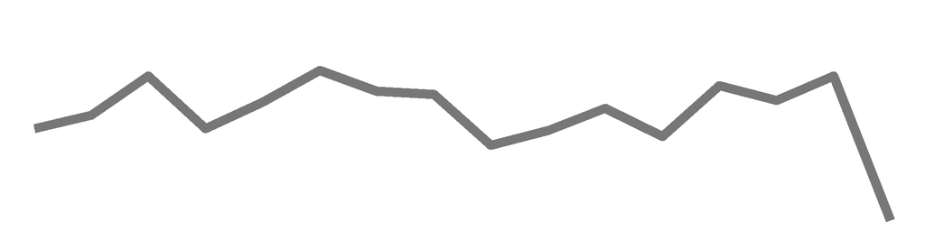

Margaret Wieczorek

8

9

9

8

11

8

9

8

5

5

7

NA

8

7

10

NA

0.0000

14

0.5463

0.4780

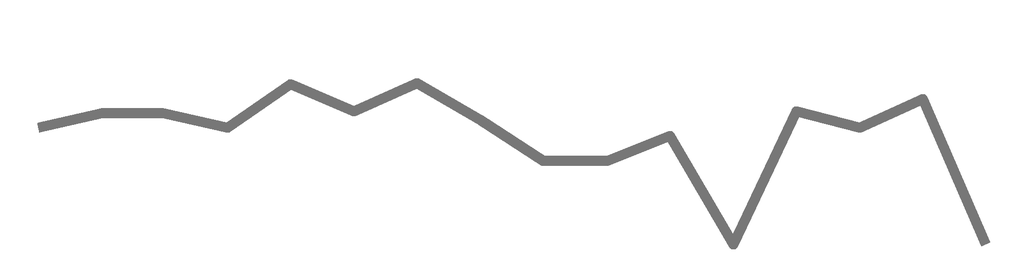

Alexander Withenbury

9

8

6

10

4

5

3

5

8

4

NA

NA

NA

NA

NA

NA

0.0000

10

0.4247

0.2654

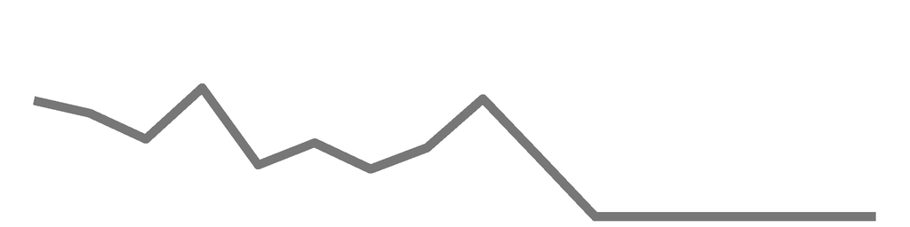

### Individual Plots

[interactive chart not shown]

# West Point Group Predictions

#### CBS Sports

This week we beat or tied 4 of 8 CBS Sports’ Experts.

For the season we are currently beating or tied with 2 of 8 CBS Sports’ Experts.

#### ESPN

We also beat or tied 3 of 9 ESPN Experts.

For the season we are currently beating or tied with 4 of 11 ESPN Experts.

### Win percentage for the week

[interactive chart not shown]

### Season Win Percent

[interactive chart not shown]

### Games Correct

145

### Games Picked

238

### Predictions

8

This Week's West Point Group Predictions

Week 16

| Game | Prediction | Winner | Correct | Correct Votes | Correct Percent |
| --- | --- | --- | --- | --- | --- |
| 1 | Tennessee Titans | Tennessee Titans | Yes | 5 | 0.625 |
| 2 | Green Bay Packers | Green Bay Packers | Yes | 8 | 1.000 |
| 3 | Arizona Cardinals | Indianapolis Colts | No | 3 | 0.375 |
| 4 | New England Patriots | Buffalo Bills | No | 3 | 0.375 |
| 5 | Cincinnati Bengals | Cincinnati Bengals | Yes | 5 | 0.625 |
| 6 | Atlanta Falcons | Atlanta Falcons | Yes | 6 | 0.750 |
| 7 | New York Jets | New York Jets | Yes | 8 | 1.000 |
| 8 | Los Angeles Chargers | Houston Texans | No | 0 | 0.000 |
| 9 | Los Angeles Rams | Los Angeles Rams | Yes | 8 | 1.000 |
| 10 | Philadelphia Eagles | Philadelphia Eagles | Yes | 8 | 1.000 |
| 11 | Tampa Bay Buccaneers | Tampa Bay Buccaneers | Yes | 8 | 1.000 |
| 12 | Seattle Seahawks | Chicago Bears | No | 1 | 0.125 |
| 13 | Denver Broncos | Las Vegas Raiders | No | 3 | 0.375 |
| 14 | Kansas City Chiefs | Kansas City Chiefs | Yes | 8 | 1.000 |
| 15 | Dallas Cowboys | Dallas Cowboys | Yes | 8 | 1.000 |
| 16 | New Orleans Saints | Miami Dolphins | No | 3 | 0.375 |

[interactive chart not shown]

# West Point Individual Predictions

#### Best Picks of the Week.

Sammy Whipple, Ryan Santoro

#### Best Season Correct Percentage

Ryan Smith

#### Best Adjusted Season Correct Percentage

Ryan Santoro

- Adjusted season percentage accounts for the number of weeks picked.

### West Point Individual Table

West Point Individual Results

Week 16

Name

Weekly # Correct

Percent

Weeks Picked

Season Percent

Adj Season Percent

Season Trend

Week 1

Week 2

Week 3

Week 4

Week 5

Week 6

Week 7

Week 8

Week 9

Week 10

Week 11

Week 12

Week 13

Week 14

Week 15

Week 16

Sammy Whipple

8

10

10

NA

10

11

10

9

7

5

11

NA

9

9

13

13

0.8125

14

0.6585

0.5762

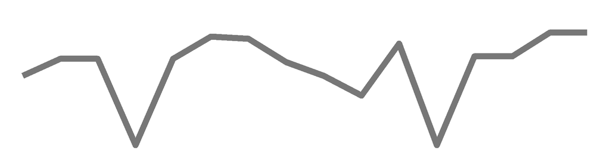

Ryan Santoro

12

11

12

11

NA

9

9

10

6

7

10

8

9

8

8

13

0.8125

15

0.6500

0.6094

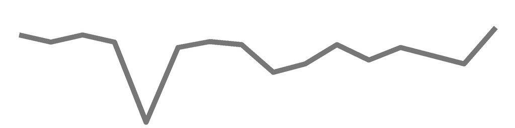

Cameron Jones

NA

11

13

8

12

8

9

9

6

6

8

11

9

10

NA

11

0.6875

14

0.6422

0.5619

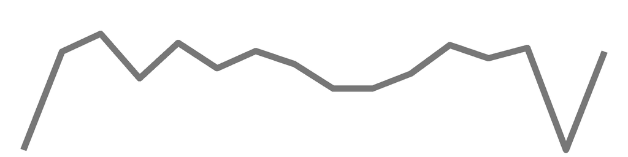

Mitchell Miller

10

7

10

9

11

9

10

8

7

6

8

9

9

10

7

11

0.6875

16

0.5975

0.5975

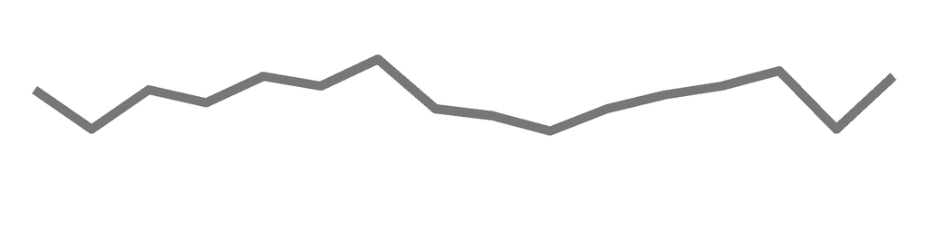

Jack Perreault

9

7

10

10

11

9

8

9

6

7

10

NA

8

NA

9

10

0.6250

14

0.5942

0.5199

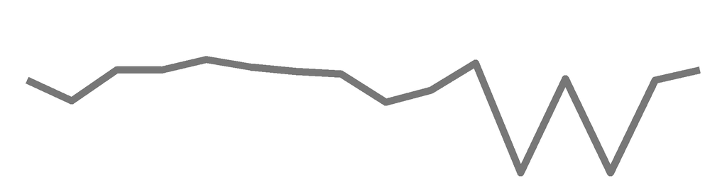

Elijah Dabkowski

NA

10

10

8

11

8

11

9

9

8

10

9

8

9

10

9

0.5625

15

0.6318

0.5923

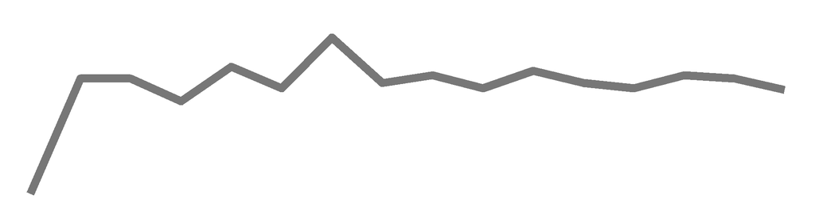

Caroline Swenson